# Machine Learning and Visualization in Python

# About the Dataset :

### Bangalore Traffic Reports.csv

The dataset represents real-world Bangalore traffic conditions including congestion levels, traffic volume, incidents, road capacity usage and environmental impact across different areas and road intersections. It helps analyze how multiple factors like weather, roadwork, public transport usage and signal compliance influence traffic flow and delays in the city. This dataset supports traffic simulation and decision-making for reducing congestion and improving transport infrastructure.

## References :

OpenCity, “Bengaluru Traffic Violations Data,” [Online]. Available: https://data.opencity.in/dataset/bengaluru-traffic-violations-data. [Accessed:06-Dec-2025].

## Dataset Importing

```python
import pandas as pd
import numpy as np

# Load dataset
df = pd.read_csv("C:/Users/asus/Downloads/Banglore_traffic_Dataset.csv")
df.head()
```

|  | Date | Area Name | Road/Intersection Name | Traffic Volume | Average Speed | Travel Time Index | Congestion Level | Road Capacity Utilization | Incident Reports | Environmental Impact | Public Transport Usage | Traffic Signal Compliance | Parking Usage | Pedestrian and Cyclist Count | Weather Conditions | Roadwork and Construction Activity |
| --- | --- | --- | --- | --- | --- | --- | --- | --- | --- | --- | --- | --- | --- | --- | --- | --- |
| 0 | 2022-01-01 | Indiranagar | 100 Feet Road | 50590 | 50.230299 | 1.500000 | 100.000000 | 100.000000 | 0 | 151.180 | 70.632330 | 84.044600 | 85.403629 | 111 | Clear | No |
| 1 | 2022-01-01 | Indiranagar | CMH Road | 30825 | 29.377125 | 1.500000 | 100.000000 | 100.000000 | 1 | 111.650 | 41.924899 | 91.407038 | 59.983689 | 100 | Clear | No |
| 2 | 2022-01-01 | Whitefield | Marathahalli Bridge | 7399 | 54.474398 | 1.039069 | 28.347994 | 36.396525 | 0 | 64.798 | 44.662384 | 61.375541 | 95.466020 | 189 | Clear | No |
| 3 | 2022-01-01 | Koramangala | Sony World Junction | 60874 | 43.817610 | 1.500000 | 100.000000 | 100.000000 | 1 | 171.748 | 32.773123 | 75.547092 | 63.567452 | 111 | Clear | No |
| 4 | 2022-01-01 | Koramangala | Sarjapur Road | 57292 | 41.116763 | 1.500000 | 100.000000 | 100.000000 | 3 | 164.584 | 35.092601 | 64.634762 | 93.155171 | 104 | Clear | No |

```python
df.head(5)
```

|  | Date | Area Name | Road/Intersection Name | Traffic Volume | Average Speed | Travel Time Index | Congestion Level | Road Capacity Utilization | Incident Reports | Environmental Impact | Public Transport Usage | Traffic Signal Compliance | Parking Usage | Pedestrian and Cyclist Count | Weather Conditions | Roadwork and Construction Activity |
| --- | --- | --- | --- | --- | --- | --- | --- | --- | --- | --- | --- | --- | --- | --- | --- | --- |
| 0 | 2022-01-01 | Indiranagar | 100 Feet Road | 50590 | 50.230299 | 1.500000 | 100.000000 | 100.000000 | 0 | 151.180 | 70.632330 | 84.044600 | 85.403629 | 111 | Clear | No |
| 1 | 2022-01-01 | Indiranagar | CMH Road | 30825 | 29.377125 | 1.500000 | 100.000000 | 100.000000 | 1 | 111.650 | 41.924899 | 91.407038 | 59.983689 | 100 | Clear | No |
| 2 | 2022-01-01 | Whitefield | Marathahalli Bridge | 7399 | 54.474398 | 1.039069 | 28.347994 | 36.396525 | 0 | 64.798 | 44.662384 | 61.375541 | 95.466020 | 189 | Clear | No |
| 3 | 2022-01-01 | Koramangala | Sony World Junction | 60874 | 43.817610 | 1.500000 | 100.000000 | 100.000000 | 1 | 171.748 | 32.773123 | 75.547092 | 63.567452 | 111 | Clear | No |
| 4 | 2022-01-01 | Koramangala | Sarjapur Road | 57292 | 41.116763 | 1.500000 | 100.000000 | 100.000000 | 3 | 164.584 | 35.092601 | 64.634762 | 93.155171 | 104 | Clear | No |

## Data information

```python
df.info()
```

```
<class 'pandas.core.frame.DataFrame'>
RangeIndex: 8936 entries, 0 to 8935
Data columns (total 16 columns):
 #   Column                              Non-Null Count  Dtype
---  ------                              --------------  -----
 0   Date                                8936 non-null   object
 1   Area Name                           8936 non-null   object
 2   Road/Intersection Name              8936 non-null   object
 3   Traffic Volume                      8936 non-null   int64
 4   Average Speed                       8936 non-null   float64
 5   Travel Time Index                   8936 non-null   float64
 6   Congestion Level                    8936 non-null   float64
 7   Road Capacity Utilization           8936 non-null   float64
 8   Incident Reports                    8936 non-null   int64
 9   Environmental Impact                8936 non-null   float64
 10  Public Transport Usage              8936 non-null   float64
 11  Traffic Signal Compliance           8936 non-null   float64
 12  Parking Usage                       8936 non-null   float64
 13  Pedestrian and Cyclist Count        8936 non-null   int64
 14  Weather Conditions                  8936 non-null   object
 15  Roadwork and Construction Activity  8936 non-null   object
dtypes: float64(8), int64(3), object(5)
memory usage: 1.1+ MB
```

```python
df.describe()
```

|  | Traffic Volume | Average Speed | Travel Time Index | Congestion Level | Road Capacity Utilization | Incident Reports | Environmental Impact | Public Transport Usage | Traffic Signal Compliance | Parking Usage | Pedestrian and Cyclist Count |
| --- | --- | --- | --- | --- | --- | --- | --- | --- | --- | --- | --- |
| count | 8936.000000 | 8936.000000 | 8936.000000 | 8936.000000 | 8936.000000 | 8936.000000 | 8936.000000 | 8936.000000 | 8936.000000 | 8936.000000 | 8936.000000 |
| mean | 29236.048120 | 39.447427 | 1.375554 | 80.818041 | 92.029215 | 1.570389 | 108.472096 | 45.086651 | 79.950243 | 75.155597 | 114.533348 |
| std | 13001.808801 | 10.707244 | 0.165319 | 23.533182 | 16.583341 | 1.420047 | 26.003618 | 20.208460 | 11.585006 | 14.409394 | 36.812573 |
| min | 4233.000000 | 20.000000 | 1.000039 | 5.160279 | 18.739771 | 0.000000 | 58.466000 | 10.006853 | 60.003933 | 50.020411 | 66.000000 |
| 25% | 19413.000000 | 31.775825 | 1.242459 | 64.292905 | 97.354990 | 0.000000 | 88.826000 | 27.341191 | 69.828270 | 62.545895 | 94.000000 |
| 50% | 27600.000000 | 39.199368 | 1.500000 | 92.389018 | 100.000000 | 1.000000 | 105.200000 | 45.170684 | 79.992773 | 75.317610 | 102.000000 |
| 75% | 38058.500000 | 46.644517 | 1.500000 | 100.000000 | 100.000000 | 2.000000 | 126.117000 | 62.426485 | 89.957358 | 87.518589 | 111.000000 |
| max | 72039.000000 | 89.790843 | 1.500000 | 100.000000 | 100.000000 | 10.000000 | 194.078000 | 79.979744 | 99.993652 | 99.995049 | 243.000000 |

```python
df.shape
```

```
(8936, 16)
```

```python
df.dtypes
```

```
Date                                   object
Area Name                              object
Road/Intersection Name                 object
Traffic Volume                          int64
Average Speed                         float64
Travel Time Index                     float64
Congestion Level                      float64
Road Capacity Utilization             float64
Incident Reports                        int64
Environmental Impact                  float64
Public Transport Usage                float64
Traffic Signal Compliance             float64
Parking Usage                         float64
Pedestrian and Cyclist Count            int64
Weather Conditions                     object
Roadwork and Construction Activity     object
dtype: object
```

## Unique Values of the column

> Unique()- to find unique/distinct values in data structures like arrays or columns

> Value_counts() is a pandas function used on a Series (column) to count how many times each unique value occurs.

```python
df.columns
```

```
Index(['Date', 'Area Name', 'Road/Intersection Name', 'Traffic Volume',
       'Average Speed', 'Travel Time Index', 'Congestion Level',
       'Road Capacity Utilization', 'Incident Reports', 'Environmental Impact',
       'Public Transport Usage', 'Traffic Signal Compliance', 'Parking Usage',
       'Pedestrian and Cyclist Count', 'Weather Conditions',
       'Roadwork and Construction Activity'],
      dtype='object')
```

```python
df.nunique()
```

```
Date                                   952
Area Name                                8
Road/Intersection Name                  16
Traffic Volume                        8100
Average Speed                         8572
Travel Time Index                     3711
Congestion Level                      5053
Road Capacity Utilization             2352
Incident Reports                        11
Environmental Impact                  8100
Public Transport Usage                8936
Traffic Signal Compliance             8936
Parking Usage                         8936
Pedestrian and Cyclist Count           148
Weather Conditions                       5
Roadwork and Construction Activity       2
dtype: int64
```

```python
df['Area Name'].unique()
```

```
array(['Indiranagar', 'Whitefield', 'Koramangala', 'M.G. Road',
       'Jayanagar', 'Hebbal', 'Yeshwanthpur', 'Electronic City'],
      dtype=object)
```

```python
df['Area Name'].value_counts()
```

```
Area Name
Indiranagar        1720
M.G. Road          1501
Koramangala        1364
Jayanagar          1173
Hebbal              950
Whitefield          942
Yeshwanthpur        734
Electronic City     552
Name: count, dtype: int64
```

```python
df['Road/Intersection Name'].unique()
```

```
array(['100 Feet Road', 'CMH Road', 'Marathahalli Bridge',
       'Sony World Junction', 'Sarjapur Road', 'Trinity Circle',
       'Anil Kumble Circle', 'Jayanagar 4th Block', 'South End Circle',
       'Hebbal Flyover', 'Ballari Road', 'Yeshwanthpur Circle',
       'Tumkur Road', 'ITPL Main Road', 'Silk Board Junction',
       'Hosur Road'], dtype=object)
```

```python
df['Road/Intersection Name'].value_counts()
```

```
Road/Intersection Name
100 Feet Road          860
CMH Road               860
Anil Kumble Circle     759
Trinity Circle         742
Sony World Junction    684
Sarjapur Road          680
South End Circle       593
Jayanagar 4th Block    580
Marathahalli Bridge    492
Ballari Road           476
Hebbal Flyover         474
ITPL Main Road         450
Yeshwanthpur Circle    373
Tumkur Road            361
Hosur Road             277
Silk Board Junction    275
Name: count, dtype: int64
```

## Imputing Missing and Null Values

```python
df.isnull().sum()
```

```
Date                                  0
Area Name                             0
Road/Intersection Name                0
Traffic Volume                        0
Average Speed                         0
Travel Time Index                     0
Congestion Level                      0
Road Capacity Utilization             0
Incident Reports                      0
Environmental Impact                  0
Public Transport Usage                0
Traffic Signal Compliance             0
Parking Usage                         0
Pedestrian and Cyclist Count          0
Weather Conditions                    0
Roadwork and Construction Activity    0
dtype: int64
```

```python
df.duplicated().sum()
```

```
0
```

## Renaming Columns

```python
df.rename(columns={
    'Date': 'Date',
    'Area Name': 'Area',
    'Road/Intersection Name': 'Road',
    'Traffic Volume': 'Traffic_Vol',
    'Average Speed': 'Avg_Speed',
    'Travel Time Index': 'TTI',
    'Congestion Level': 'Cong_Level',
    'Road Capacity Utilization': 'Capacity_Util',
    'Incident Reports': 'Incidents',
    'Environmental Impact': 'Env_Impact',
    'Public Transport Usage': 'PT_Usage',
    'Traffic Signal Compliance': 'Signal_Compliance',
    'Parking Usage': 'Parking',
    'Pedestrian and Cyclist Count': 'Ped_Cycle',
    'Weather Conditions': 'Weather',
    'Roadwork and Construction Activity': 'Roadwork'
}, inplace=True)
```

```python
df.columns
```

[output not shown]

```python
df.columns = df.columns.str.replace("'", "").str.strip()
```

## Converting Strings to Numeric

> to_numeric() is used in pandas to convert values into numeric data types (like integers or floats)

```python
numeric_cols = ['Traffic_Vol', 'Avg_Speed', 'TTI', 'Cong_Level', 'Capacity_Util']

df[numeric_cols] = df[numeric_cols].apply(pd.to_numeric, errors='coerce')
df[numeric_cols] = df[numeric_cols].fillna(0)

print(df[numeric_cols].info())
print(df.head())
```

```
<class 'pandas.core.frame.DataFrame'>
RangeIndex: 8936 entries, 0 to 8935
Data columns (total 5 columns):
 #   Column         Non-Null Count  Dtype
---  ------         --------------  -----
 0   Traffic_Vol    8936 non-null   int64
 1   Avg_Speed      8936 non-null   float64
 2   TTI            8936 non-null   float64
 3   Cong_Level     8936 non-null   float64
 4   Capacity_Util  8936 non-null   float64
dtypes: float64(4), int64(1)
memory usage: 349.2 KB
None
         Date         Area                 Road  Traffic_Vol  Avg_Speed  \
0  2022-01-01  Indiranagar        100 Feet Road        50590  50.230299
1  2022-01-01  Indiranagar             CMH Road        30825  29.377125
2  2022-01-01   Whitefield  Marathahalli Bridge         7399  54.474398
3  2022-01-01  Koramangala  Sony World Junction        60874  43.817610
4  2022-01-01  Koramangala        Sarjapur Road        57292  41.116763

        TTI  Cong_Level  Capacity_Util  Incidents  Env_Impact   PT_Usage  \
0  1.500000  100.000000     100.000000          0     151.180  70.632330
1  1.500000  100.000000     100.000000          1     111.650  41.924899
2  1.039069   28.347994      36.396525          0      64.798  44.662384
3  1.500000  100.000000     100.000000          1     171.748  32.773123
4  1.500000  100.000000     100.000000          3     164.584  35.092601

   Signal_Compliance    Parking  Ped_Cycle Weather Roadwork
0          84.044600  85.403629        111   Clear       No
1          91.407038  59.983689        100   Clear       No
2          61.375541  95.466020        189   Clear       No
3          75.547092  63.567452        111   Clear       No
4          64.634762  93.155171        104   Clear       No
```

## Cleaned Dataset

```python
df.head(2)
```

|  | Date | Area | Road | Traffic_Vol | Avg_Speed | TTI | Cong_Level | Capacity_Util | Incidents | Env_Impact | PT_Usage | Signal_Compliance | Parking | Ped_Cycle | Weather | Roadwork |
| --- | --- | --- | --- | --- | --- | --- | --- | --- | --- | --- | --- | --- | --- | --- | --- | --- |
| 0 | 2022-01-01 | Indiranagar | 100 Feet Road | 50590 | 50.230299 | 1.5 | 100.0 | 100.0 | 0 | 151.18 | 70.632330 | 84.044600 | 85.403629 | 111 | Clear | No |
| 1 | 2022-01-01 | Indiranagar | CMH Road | 30825 | 29.377125 | 1.5 | 100.0 | 100.0 | 1 | 111.65 | 41.924899 | 91.407038 | 59.983689 | 100 | Clear | No |

## Group BY :

#### Calculate the average congestion level in each area of Bangalore

```python
df.groupby('Area')['Cong_Level'].mean().reset_index(name='Avg_Congestion').sort_values(by='Avg_Congestion', ascending=False)
```

|  | Area | Avg_Congestion |
| --- | --- | --- |
| 4 | Koramangala | 93.985536 |
| 5 | M.G. Road | 90.579670 |
| 2 | Indiranagar | 87.641890 |
| 1 | Hebbal | 80.087244 |
| 3 | Jayanagar | 76.998324 |
| 6 | Whitefield | 69.054661 |
| 7 | Yeshwanthpur | 62.369634 |
| 0 | Electronic City | 54.454507 |

#### Roads are sorted to identify the busiest routes with the highest overall traffic flow.

```python
df.groupby('Road')['Traffic_Vol'].sum().reset_index(name='Total_Traffic').sort_values(by='Total_Traffic', ascending=False)
```

|  | Road | Total_Traffic |
| --- | --- | --- |
| 11 | Sony World Junction | 28366028 |
| 3 | CMH Road | 28046255 |
| 0 | 100 Feet Road | 27482893 |
| 9 | Sarjapur Road | 27329166 |
| 1 | Anil Kumble Circle | 26756138 |
| 13 | Trinity Circle | 26229802 |
| 12 | South End Circle | 14649543 |
| 7 | Jayanagar 4th Block | 14207817 |
| 4 | Hebbal Flyover | 12700794 |
| 2 | Ballari Road | 12505777 |
| 8 | Marathahalli Bridge | 10220293 |
| 6 | ITPL Main Road | 9839717 |
| 15 | Yeshwanthpur Circle | 7190364 |
| 14 | Tumkur Road | 6705391 |
| 5 | Hosur Road | 4586351 |
| 10 | Silk Board Junction | 4436997 |

#### Calculates the total number of traffic-related incidents reported per area

```python
df.groupby('Area')['Incidents'].sum().reset_index(name='Total_Incidents').sort_values(by='Total_Incidents', ascending=False)
```

|  | Area | Total_Incidents |
| --- | --- | --- |
| 2 | Indiranagar | 3057 |
| 5 | M.G. Road | 2799 |
| 4 | Koramangala | 2519 |
| 3 | Jayanagar | 1740 |
| 1 | Hebbal | 1489 |
| 6 | Whitefield | 1202 |
| 7 | Yeshwanthpur | 796 |
| 0 | Electronic City | 431 |

#### Summary report of average traffic flow, congestion, and speed for each area

```python
df.groupby('Area').agg({
    'Traffic_Vol': 'mean',       # Average traffic density
    'Cong_Level': 'mean',        # Congestion severity
    'Avg_Speed': 'mean'          # Flow efficiency
}).reset_index()
```

|  | Area | Traffic_Vol | Cong_Level | Avg_Speed |
| --- | --- | --- | --- | --- |
| 0 | Electronic City | 16346.644928 | 54.454507 | 43.661789 |
| 1 | Hebbal | 26533.232632 | 80.087244 | 40.149855 |
| 2 | Indiranagar | 32284.388372 | 87.641890 | 38.644341 |
| 3 | Jayanagar | 24601.329923 | 76.998324 | 39.789692 |
| 4 | Koramangala | 40832.253666 | 93.985536 | 36.062629 |
| 5 | M.G. Road | 35300.426382 | 90.579670 | 37.535189 |
| 6 | Whitefield | 21295.127389 | 69.054661 | 42.140866 |
| 7 | Yeshwanthpur | 18931.546322 | 62.369634 | 43.447576 |

#### Counts total traffic accidents and pedestrian/cyclist incidents in each area

```python
df.groupby('Area').agg({
    'Incidents': 'sum',
    'Ped_Cycle': 'sum'
}).reset_index().sort_values(by='Incidents', ascending=False)
```

|  | Area | Incidents | Ped_Cycle |
| --- | --- | --- | --- |
| 2 | Indiranagar | 3057 | 189780 |
| 5 | M.G. Road | 2799 | 164284 |
| 4 | Koramangala | 2519 | 142732 |
| 3 | Jayanagar | 1740 | 130876 |
| 1 | Hebbal | 1489 | 106199 |
| 6 | Whitefield | 1202 | 113921 |
| 7 | Yeshwanthpur | 796 | 96478 |
| 0 | Electronic City | 431 | 79200 |

#### Checks how much of the road capacity is used (overloading or underutilization)

```python
df.groupby('Road').agg({
    'Capacity_Util': 'mean',
    'Parking': 'mean'
}).reset_index()
```

|  | Road | Capacity_Util | Parking |
| --- | --- | --- | --- |
| 0 | 100 Feet Road | 95.669339 | 75.378643 |
| 1 | Anil Kumble Circle | 96.609093 | 74.401622 |
| 2 | Ballari Road | 92.630587 | 74.930990 |
| 3 | CMH Road | 95.848204 | 75.708944 |
| 4 | Hebbal Flyover | 92.813665 | 76.557755 |
| 5 | Hosur Road | 77.583447 | 75.860093 |
| 6 | ITPL Main Road | 88.340567 | 76.100602 |
| 7 | Jayanagar 4th Block | 91.533435 | 74.935616 |
| 8 | Marathahalli Bridge | 85.539280 | 75.144332 |
| 9 | Sarjapur Road | 97.391909 | 74.288298 |
| 10 | Silk Board Junction | 74.923904 | 75.714098 |
| 11 | Sony World Junction | 97.462395 | 75.090172 |
| 12 | South End Circle | 91.504732 | 75.300451 |
| 13 | Trinity Circle | 96.498600 | 74.656480 |
| 14 | Tumkur Road | 82.180902 | 75.439871 |
| 15 | Yeshwanthpur Circle | 82.602769 | 73.875010 |

# Pivot Table

#### Shows how traffic volume changes over time in different areas. Helps identify traffic-peak days and worst-affected regions.

```python
pivot_traffic = df.pivot_table(
    values='Traffic_Vol',
    index='Date',
    columns='Area',
    aggfunc='mean'
)
pivot_traffic
```

| Area Date | Electronic City | Hebbal | Indiranagar | Jayanagar | Koramangala | M.G. Road | Whitefield | Yeshwanthpur |
| --- | --- | --- | --- | --- | --- | --- | --- | --- |
| 2022-01-01 | NaN | 35103.0 | 40707.5 | 25200.5 | 59083.0 | 42211.0 | 7399.0 | 15043.0 |
| 2022-01-02 | NaN | 18483.5 | 29963.5 | 27092.5 | 29106.0 | 45400.5 | NaN | 18005.5 |
| 2022-01-03 | NaN | NaN | 31191.0 | 10179.0 | 39970.0 | NaN | 17061.0 | NaN |
| 2022-01-04 | NaN | NaN | 51220.5 | 16342.0 | 29798.5 | 38874.5 | 16920.5 | 17659.0 |
| 2022-01-05 | NaN | 38924.0 | 41961.0 | 20301.0 | 52941.5 | NaN | 17018.0 | 20518.0 |
| ... | ... | ... | ... | ... | ... | ... | ... | ... |
| 2024-08-05 | 18127.0 | 30538.0 | 17963.0 | NaN | 45301.0 | 25262.0 | 24916.0 | NaN |
| 2024-08-06 | 14428.0 | 8985.0 | 34938.5 | NaN | 55668.5 | 31846.5 | 24933.0 | 16736.5 |
| 2024-08-07 | 15234.0 | 22027.0 | 24057.0 | NaN | 37130.0 | 12957.5 | 16472.5 | 21547.0 |
| 2024-08-08 | 28605.0 | 19186.0 | 52465.0 | 21897.5 | 34286.5 | 27399.0 | 23999.0 | NaN |
| 2024-08-09 | 11387.0 | NaN | 35302.0 | 20540.0 | 43332.5 | 39649.5 | NaN | 14705.0 |

952 rows × 8 columns

#### Gives average congestion score for each major road and ranks them. Helps locate most congested roads for traffic planning.

```python
pivot_congestion = df.pivot_table(
    values='Cong_Level',
    index='Road',
    aggfunc='mean'
).sort_values(by='Cong_Level', ascending=False)
pivot_congestion
```

| Road | Cong_Level |
| --- | --- |
| Sony World Junction | 94.125087 |
| Sarjapur Road | 93.845163 |
| Anil Kumble Circle | 90.782145 |
| Trinity Circle | 90.372556 |
| CMH Road | 88.176365 |
| 100 Feet Road | 87.107415 |
| Hebbal Flyover | 80.662354 |
| Ballari Road | 79.514551 |
| South End Circle | 77.277398 |
| Jayanagar 4th Block | 76.712995 |
| ITPL Main Road | 71.101106 |
| Marathahalli Bridge | 67.182913 |
| Yeshwanthpur Circle | 63.744162 |
| Tumkur Road | 60.949415 |
| Hosur Road | 55.203745 |
| Silk Board Junction | 53.699820 |

#### Shows how weather affects accident frequency in different areas. Helps in safety planning during rain/fog conditions

```python
pivot_incidents_weather = df.pivot_table(
    values='Incidents',
    index='Area',
    columns='Weather',
    aggfunc='sum',
    fill_value=0
)
pivot_incidents_weather
```

| Weather Area | Clear | Fog | Overcast | Rain | Windy |
| --- | --- | --- | --- | --- | --- |
| Electronic City | 251 | 46 | 69 | 41 | 24 |
| Hebbal | 883 | 157 | 239 | 145 | 65 |
| Indiranagar | 1890 | 345 | 430 | 234 | 158 |
| Jayanagar | 1005 | 195 | 278 | 186 | 76 |
| Koramangala | 1507 | 261 | 376 | 245 | 130 |
| M.G. Road | 1719 | 318 | 361 | 265 | 136 |
| Whitefield | 733 | 134 | 184 | 99 | 52 |
| Yeshwanthpur | 485 | 95 | 107 | 68 | 41 |

# Data Visualization

### Import Visualization Tools and Packages

```python
import pandas as pd
import matplotlib.pyplot as plt
import seaborn as sns

sns.set(style="whitegrid")
```

### Bar Charts

#### Top 10 Most Congested Roads in Bangalore

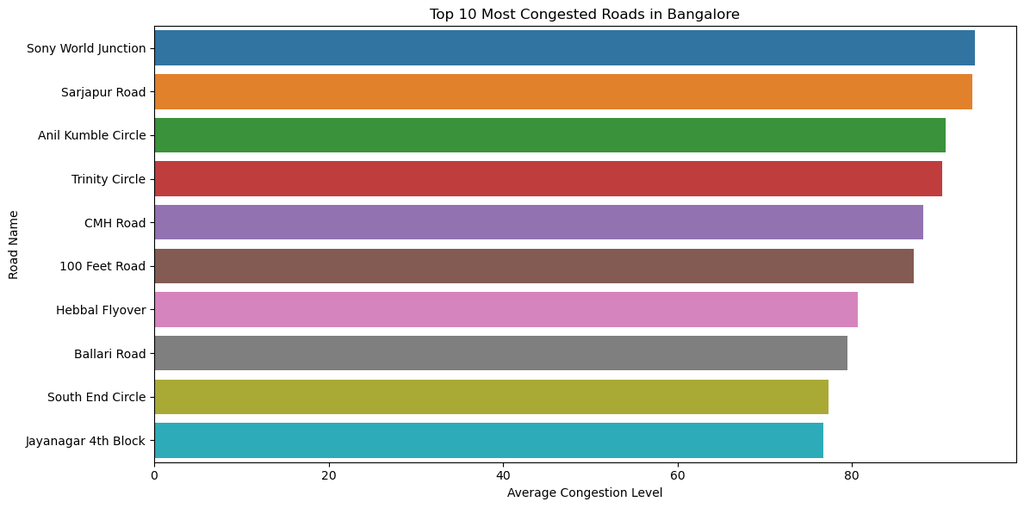

```python
top_congested = df.groupby('Road')['Cong_Level'].mean().sort_values(ascending=False).head(10)
plt.figure(figsize=(12,6))
sns.barplot(
    x=top_congested.values,
    y=top_congested.index,
    palette='tab10'  # You can also try 'Set2', 'Paired', 'viridis', etc.
)

plt.title("Top 10 Most Congested Roads in Bangalore")
plt.xlabel("Average Congestion Level")
plt.ylabel("Road Name")
plt.tight_layout()
plt.show()
```

## Average Traffic Volume by Area

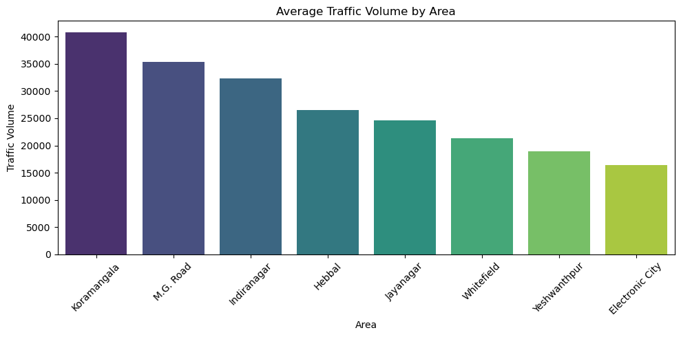

```python
traffic_area = df.groupby('Area')['Traffic_Vol'].mean().sort_values(ascending=False)
plt.figure(figsize=(10,5))
sns.barplot(
    x=traffic_area.index,
    y=traffic_area.values,
    palette='viridis'  # You can also try 'coolwarm', 'Set2', 'rainbow'
)

plt.xticks(rotation=45)
plt.title("Average Traffic Volume by Area")
plt.xlabel("Area")
plt.ylabel("Traffic Volume")
plt.tight_layout()
plt.show()
```

### Incident Report by Weather Condition

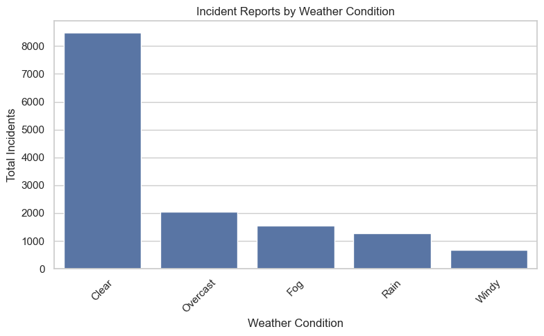

```python
incidents_weather = df.groupby('Weather')['Incidents'].sum().sort_values(ascending=False)

plt.figure(figsize=(8,5))
sns.barplot(x=incidents_weather.index, y=incidents_weather.values)
plt.xticks(rotation=45)
plt.title("Incident Reports by Weather Condition")
plt.xlabel("Weather Condition")
plt.ylabel("Total Incidents")
plt.tight_layout()
plt.show()
incidents_weather = df.groupby('Weather')['Incidents'].sum().sort_values(ascending=False)
```

## PIE Chart

#### Traffic Volume Share by Area

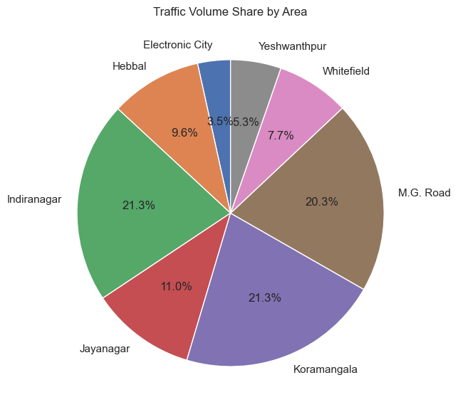

```python
traffic_area = df.groupby('Area')['Traffic_Vol'].sum()

plt.figure(figsize=(7,7))
plt.pie(traffic_area, labels=traffic_area.index, autopct='%1.1f%%', startangle=90)
plt.title("Traffic Volume Share by Area")
plt.show()
```

### Incidents by Weather Condition

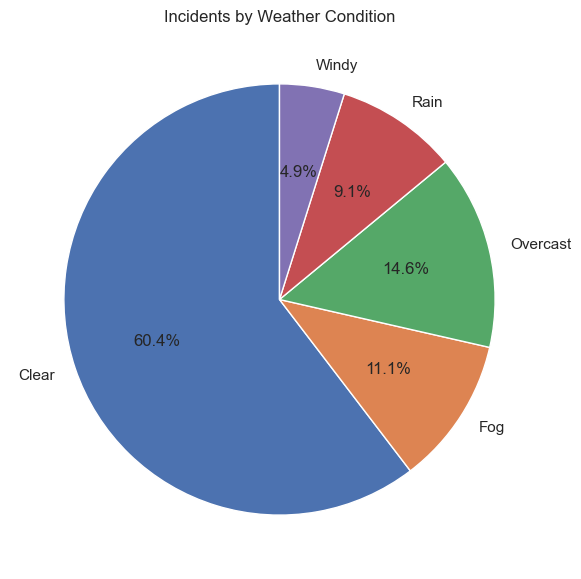

```python
incidents_weather = df.groupby('Weather')['Incidents'].sum()

plt.figure(figsize=(7,7))
plt.pie(incidents_weather, labels=incidents_weather.index, autopct='%1.1f%%', startangle=90)
plt.title("Incidents by Weather Condition")
plt.show()
```

## Line Chart

### Traffic Volume trend in Bangalore

##### ( We notice the chart is congested due to huge records)

[figure not shown]

```python
import pandas as pd
import matplotlib.pyplot as plt
from scipy.ndimage import gaussian_filter1d

df['Date'] = pd.to_datetime(df['Date'], errors='coerce')
df = df.sort_values(by='Date')
df['Traffic_Trend'] = gaussian_filter1d(df['Traffic Volume'], sigma=2)

# Plot Trend Line
plt.figure(figsize=(12,6))
plt.plot(df['Date'], df['Traffic_Trend'], linewidth=3)
plt.title("Traffic Volume Trend in Bangalore")
plt.xlabel("Date")
plt.ylabel("Traffic Volume (Trend)")
plt.xticks(rotation=45)
plt.grid(True, linestyle="--", alpha=0.5)
plt.tight_layout()
plt.show()
```

### Traffic Volume trend over time

#### (Simple less Congestion lin chart)

```python
import pandas as pd
import matplotlib.pyplot as plt

# Convert Date to datetime
df['Date'] = pd.to_datetime(df['Date'], errors='coerce')

# Sort date
df = df.sort_values(by='Date')

# Reduce congestion by taking every 10th row
df_sample = df.iloc[::10]
```

[figure not shown]

```python
plt.figure(figsize=(12,5))
plt.plot(df_sample['Date'], df_sample['Traffic Volume'], linewidth=2)
plt.title("Traffic Volume Trend Over Time - Bangalore")
plt.xlabel("Date")
plt.ylabel("Traffic Volume")
plt.grid(True, linestyle='--', alpha=0.4)
plt.xticks(rotation=45)
plt.tight_layout()
plt.show()
```

### Congestion Level over Time

[figure not shown]

```python
plt.figure(figsize=(12,5))
plt.plot(df_sample['Date'], df_sample['Congestion Level'], linewidth=2, marker='o', markersize=3)
plt.title("Congestion Level Trend Over Time - Bangalore")
plt.xlabel("Date")
plt.ylabel("Congestion Level")
plt.grid(True, linestyle='--', alpha=0.4)
plt.xticks(rotation=45)
plt.tight_layout()
plt.show()
```

### Traffic Incidents Trend over Time

[figure not shown]

```python
plt.figure(figsize=(12,5))
plt.plot(df_sample['Date'], df_sample['Incident Reports'], linewidth=2, marker='o', markersize=3)
plt.title("Traffic Incidents Trend Over Time - Bangalore")
plt.xlabel("Date")
plt.ylabel("Incident Reports")
plt.grid(True, linestyle='--', alpha=0.4)
plt.xticks(rotation=45)
plt.tight_layout()
plt.show()
```

## Scatter Plot

### Traffic Volume vs Average Speed

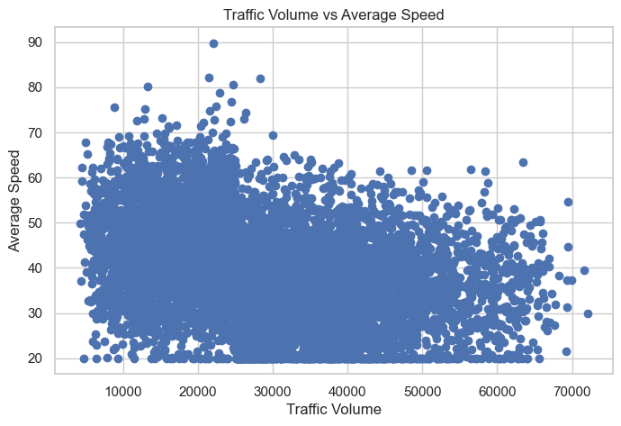

```python
plt.figure(figsize=(8,5))
plt.scatter(df['Traffic_Vol'], df['Avg_Speed'])
plt.xlabel('Traffic Volume')
plt.ylabel('Average Speed')
plt.title('Traffic Volume vs Average Speed')
plt.show()
```

### Congestion Level vs Travel Time Index

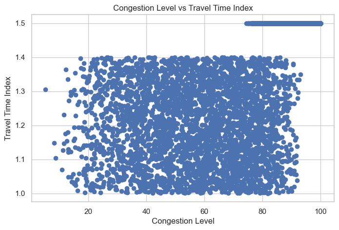

```python
plt.figure(figsize=(8,5))
plt.scatter(df['Cong_Level'], df['TTI'])
plt.xlabel('Congestion Level')
plt.ylabel('Travel Time Index')
plt.title('Congestion Level vs Travel Time Index')
plt.show()
```

### Incidents vs Traffic Volume

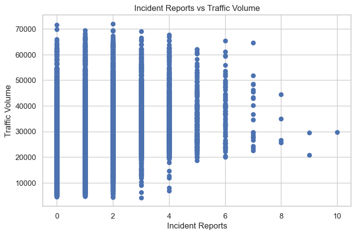

```python
plt.figure(figsize=(8,5))
plt.scatter(df['Incidents'], df['Traffic_Vol'])
plt.xlabel('Incident Reports')
plt.ylabel('Traffic Volume')
plt.title('Incident Reports vs Traffic Volume')
plt.show()
```

## Histogram

### Distribution of traffic volume

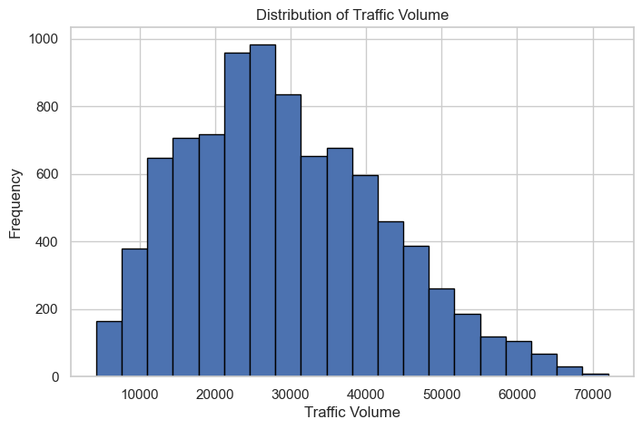

```python
plt.figure(figsize=(8,5))
plt.hist(df['Traffic_Vol'], bins=20, edgecolor='black')
plt.xlabel('Traffic Volume')
plt.ylabel('Frequency')
plt.title('Distribution of Traffic Volume')
plt.show()
```

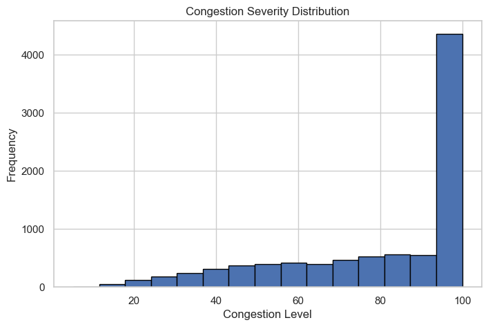

```python
plt.figure(figsize=(8,5))
plt.hist(df['Cong_Level'], bins=15, edgecolor='black')
plt.xlabel('Congestion Level')
plt.ylabel('Frequency')
plt.title('Congestion Severity Distribution')
plt.show()
```

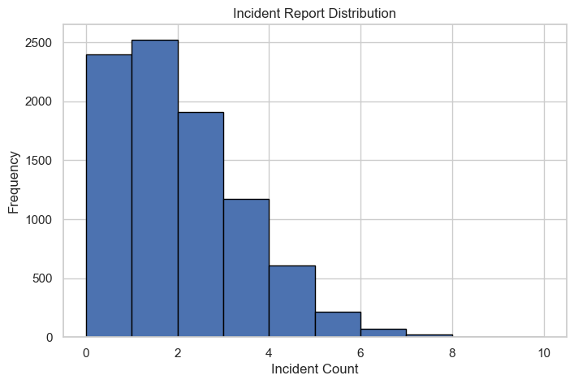

```python
plt.figure(figsize=(8,5))
plt.hist(df['Incidents'], bins=10, edgecolor='black')
plt.xlabel('Incident Count')
plt.ylabel('Frequency')
plt.title('Incident Report Distribution')
plt.show()
```

### Pyramid Chart

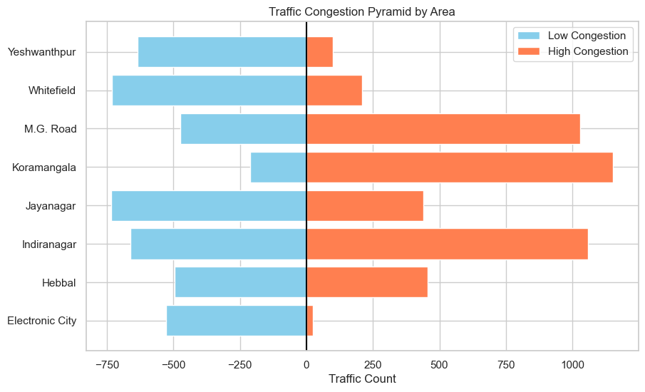

```python
import matplotlib.pyplot as plt
import pandas as pd

# Grouping congestion as high vs low
df['Cong_Category'] = df['Cong_Level'].apply(lambda x: 'High' if x >= df['Cong_Level'].median() else 'Low')

pyramid = df.groupby(['Area', 'Cong_Category']).size().unstack(fill_value=0)

# Take only top 8 areas to avoid clutter
pyramid = pyramid.head(8)

left = -pyramid['Low']
right = pyramid['High']

plt.figure(figsize=(10,6))
plt.barh(pyramid.index, left, color='skyblue', label='Low Congestion')
plt.barh(pyramid.index, right, color='coral', label='High Congestion')

plt.axvline(0, color='black')
plt.xlabel("Traffic Count")
plt.title("Traffic Congestion Pyramid by Area")
plt.legend()
plt.show()
```

## 2D Line Chart

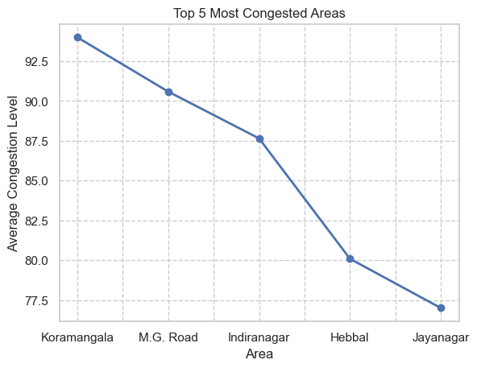

```python
top_areas = df.groupby('Area')['Cong_Level'].mean().nlargest(5)
top_areas.plot(kind='line', marker='o', linewidth=2)

plt.xlabel("Area")
plt.ylabel("Average Congestion Level")
plt.title("Top 5 Most Congested Areas")
plt.grid(True, linestyle='--')
plt.show()
```

## 2D Scatter Plot

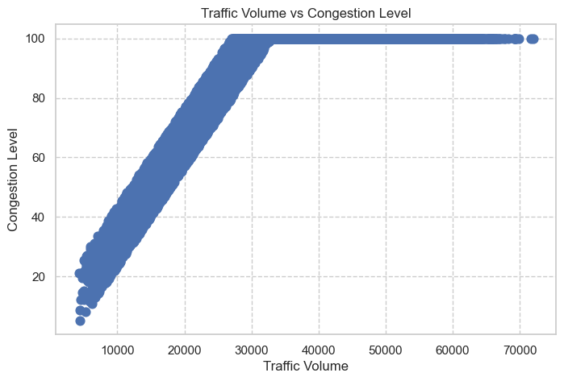

```python
import matplotlib.pyplot as plt

plt.figure(figsize=(8,5))
plt.scatter(df['Traffic_Vol'], df['Cong_Level'], s=60)

plt.xlabel("Traffic Volume")
plt.ylabel("Congestion Level")
plt.title("Traffic Volume vs Congestion Level")
plt.grid(True, linestyle='--')
plt.show()
```

## HeatMap

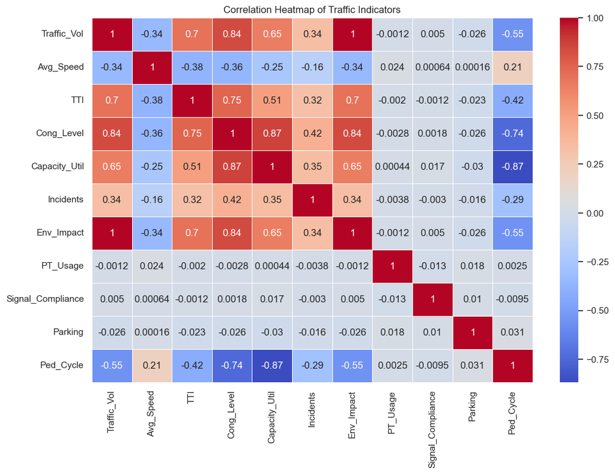

```python
import matplotlib.pyplot as plt
import seaborn as sns

# Select only numeric columns
numeric_cols = [
    'Traffic_Vol', 'Avg_Speed', 'TTI', 'Cong_Level',
    'Capacity_Util', 'Incidents', 'Env_Impact',
    'PT_Usage', 'Signal_Compliance', 'Parking', 'Ped_Cycle'
]

plt.figure(figsize=(12,8))
sns.heatmap(df[numeric_cols].corr(), annot=True, cmap='coolwarm', linewidths=0.5)
plt.title("Correlation Heatmap of Traffic Indicators")
plt.show()
```

# Machine Learning

## Random Forest Regressor

### Congestion Prediction

```python
import pandas as pd
from sklearn.model_selection import train_test_split
from sklearn.preprocessing import LabelEncoder
from sklearn.metrics import mean_squared_error, r2_score
from sklearn.ensemble import RandomForestRegressor

features = ['Traffic_Vol', 'Avg_Speed', 'Incidents', 'Weather', 'Area', 'Road']

df = df[features + ['Cong_Level']]

# Convert categorical columns
label = LabelEncoder()
df['Weather'] = label.fit_transform(df['Weather'].astype(str))
df['Area'] = label.fit_transform(df['Area'].astype(str))
df['Road'] = label.fit_transform(df['Road'].astype(str))

# Handle missing values
df = df.dropna()

# Train-Test Split
X = df.drop('Cong_Level', axis=1)
y = df['Cong_Level']

X_train, X_test, y_train, y_test = train_test_split(X, y, test_size=0.2, random_state=42)

# Model
model = RandomForestRegressor(n_estimators=200, random_state=42)
model.fit(X_train, y_train)

# Predict
y_pred = model.predict(X_test)

# Performance
mse = mean_squared_error(y_test, y_pred)
r2 = r2_score(y_test, y_pred)

print("MSE:", mse)
print("R2 Score:", r2)

# Feature Importance
importance = pd.DataFrame({
    'Feature': X.columns,
    'Importance': model.feature_importances_
}).sort_values(by='Importance', ascending=False)

print("\nFeature Importance:")
print(importance)
```

[output not shown]

```
MSE: 19.435530805703653
R2 Score: 0.9640726714741537

Feature Importance:
       Feature  Importance
0  Traffic_Vol    0.977345
1    Avg_Speed    0.010130
2    Incidents    0.004012
5         Road    0.003803
4         Area    0.002384
3      Weather    0.002326
```

#### In Bangalore’s traffic dataset, Traffic Volume is the strongest determinant of congestion, contributing about 98% to congestion level predictions. Other factors such as speed, incidents, road design, area, and weather have a much smaller influence in this dataset.

## Feature importance in Congestion Prediction

```python
importance_values = model.feature_importances_
feature_names = X_train.columns
feature_importance = pd.DataFrame({
    'Feature': feature_names,
    'Importance': importance_values
}).sort_values(by='Importance', ascending=False)
print(feature_importance)
```

```
       Feature  Importance
0  Traffic_Vol    0.977345
1    Avg_Speed    0.010130
2    Incidents    0.004012
5         Road    0.003803
4         Area    0.002384
3      Weather    0.002326
```

### Visualization of Feature Importance

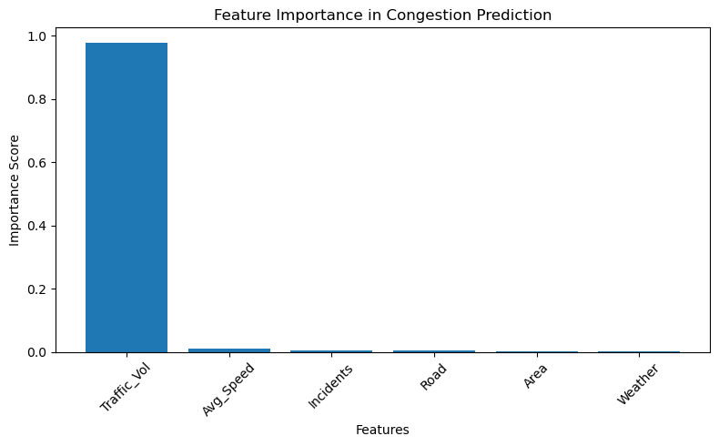

```python
plt.figure(figsize=(8,5))
plt.bar(feature_importance['Feature'], feature_importance['Importance'])
plt.title("Feature Importance in Congestion Prediction")
plt.xlabel("Features")
plt.ylabel("Importance Score")
plt.xticks(rotation=45)
plt.tight_layout()
plt.show()
```

### Actual Congestion VS Predicted Congestion

```python
results = pd.DataFrame({
    'Actual Congestion': y_test.values,
    'Predicted Congestion': y_pred
})

print(results.head(10))
```

```
   Actual Congestion  Predicted Congestion
0         100.000000            100.000000
1         100.000000            100.000000
2          79.106799             78.709348
3          73.844329             77.217905
4          59.958537             57.314288
5          87.494419             88.142320
6          56.527237             54.941103
7          84.363226             87.581797
8          78.961834             89.892113
9         100.000000            100.000000
```

### Visulization of Actual Vs Predicted Congestion Level

#### Line Chart

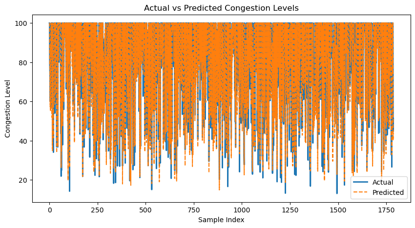

```python
import matplotlib.pyplot as plt

plt.figure(figsize=(10,5))
plt.plot(y_test.values, label='Actual', linewidth=2)
plt.plot(y_pred, label='Predicted', linestyle='--')
plt.title("Actual vs Predicted Congestion Levels")
plt.ylabel("Congestion Level")
plt.xlabel("Sample Index")
plt.legend()
plt.show()
```

### Scatter Plot

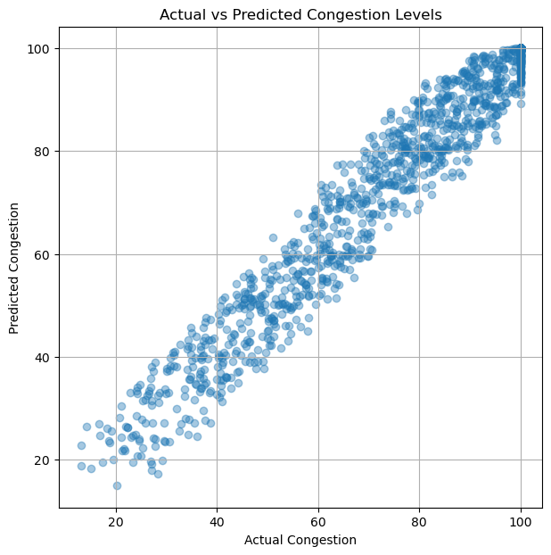

```python
plt.figure(figsize=(7,7))
plt.scatter(y_test, y_pred, alpha=0.4)
plt.title("Actual vs Predicted Congestion Levels")
plt.xlabel("Actual Congestion")
plt.ylabel("Predicted Congestion")
plt.grid(True)
plt.show()
```

```python
df['Predicted_Cong_Level'] = model.predict(X)
df.head()
```

|  | Traffic_Vol | Avg_Speed | Incidents | Weather | Area | Road | Cong_Level | Predicted_Cong_Level |
| --- | --- | --- | --- | --- | --- | --- | --- | --- |
| 0 | 50590 | 50.230299 | 0 | 0 | 2 | 0 | 100.000000 | 100.000000 |
| 1 | 30825 | 29.377125 | 1 | 0 | 2 | 3 | 100.000000 | 99.520374 |
| 2 | 7399 | 54.474398 | 0 | 0 | 6 | 8 | 28.347994 | 27.214137 |
| 3 | 60874 | 43.817610 | 1 | 0 | 4 | 11 | 100.000000 | 100.000000 |
| 4 | 57292 | 41.116763 | 3 | 0 | 4 | 9 | 100.000000 | 100.000000 |

## Congestion Prediction for next Year 2025

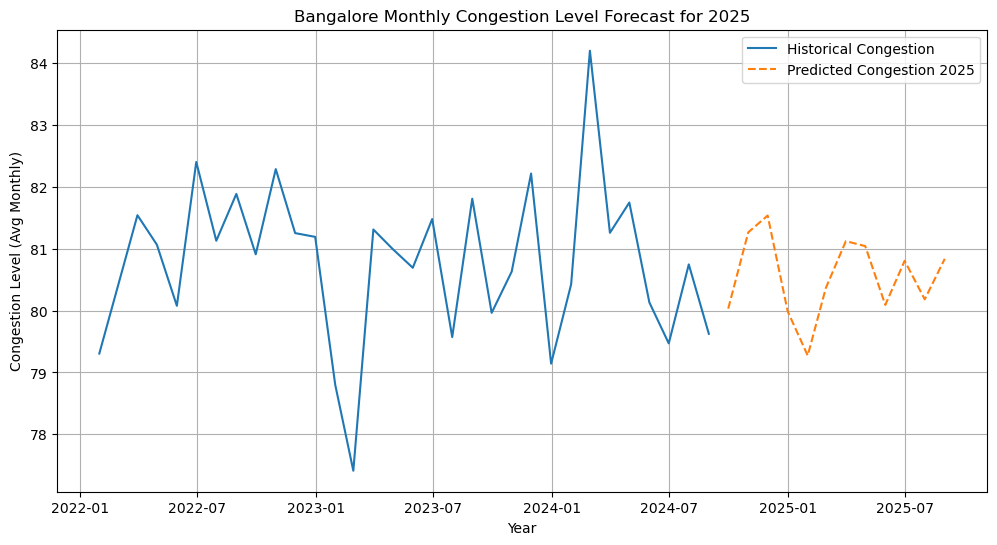

[output not shown]

```python
import pandas as pd
import matplotlib.pyplot as plt
from statsmodels.tsa.statespace.sarimax import SARIMAX

# Convert Date column to datetime format
df['Date'] = pd.to_datetime(df['Date'])

# Sort by Date to ensure proper time order
df = df.sort_values('Date')

# Convert to monthly average congestion
monthly_data = df.resample('ME', on='Date')["Congestion Level"].mean()

# Train SARIMA Model
model = SARIMAX(monthly_data, order=(1,1,1), seasonal_order=(1,1,1,12))
model_fit = model.fit()

# Forecast for 2025 (12 months)
forecast_steps = 12
forecast = model_fit.forecast(steps=forecast_steps)

# Create a date index for forecast
future_dates = pd.date_range(start=monthly_data.index[-1], periods=forecast_steps+1, freq='ME')[1:]
forecast.index = future_dates

# Plot historical + predicted congestion
plt.figure(figsize=(12,6))
plt.plot(monthly_data, label="Historical Congestion")
plt.plot(forecast, linestyle='--', label="Predicted Congestion 2025")
plt.title("Bangalore Monthly Congestion Level Forecast for 2025")
plt.xlabel("Year")
plt.ylabel("Congestion Level (Avg Monthly)")
plt.legend()
plt.grid(True)
plt.show()

# Print forecast values
print("Predicted Congestion Levels (Monthly - 2025):")
print(forecast)
```

## Weather Reports for Traffic Modeling

```python
col_weather = 'Weather Conditions'
col_cong = 'Congestion Level'
col_vol = 'Traffic Volume'
col_inc = 'Incident Reports'

# Convert Date properly + sort
df['Date'] = pd.to_datetime(df['Date'], errors='coerce')
df = df.sort_values('Date').dropna(subset=['Date'])

# Set Date as index for resampling
df = df.set_index('Date')

# Create weather dummy variables
weather_dummies = pd.get_dummies(df[col_weather].astype(str))

# Monthly aggregation
weather_monthly = weather_dummies.resample('ME').sum()

# Monthly metrics from main columns
monthly = df.resample('ME').agg({
    col_cong: 'mean',
    col_vol: 'sum',
    col_inc: 'sum'
})

# Merge weather + main features
monthly_exog = pd.concat([monthly[[col_inc]], weather_monthly], axis=1).fillna(0)

print("Monthly dataset ready:")
print(monthly_exog.head())
```

[output not shown]

```python
monthly_exog
```

| Date | Incident Reports | Clear | Fog | Overcast | Rain | Windy |
| --- | --- | --- | --- | --- | --- | --- |
| 2022-01-31 | 435 | 180 | 26 | 41 | 24 | 13 |
| 2022-02-28 | 424 | 154 | 29 | 45 | 28 | 13 |
| 2022-03-31 | 456 | 181 | 37 | 55 | 23 | 9 |
| 2022-04-30 | 470 | 178 | 33 | 32 | 20 | 11 |
| 2022-05-31 | 500 | 180 | 29 | 36 | 24 | 12 |
| 2022-06-30 | 447 | 170 | 29 | 37 | 38 | 11 |
| 2022-07-31 | 492 | 193 | 27 | 42 | 22 | 15 |
| 2022-08-31 | 476 | 189 | 31 | 34 | 27 | 14 |
| 2022-09-30 | 410 | 179 | 26 | 32 | 26 | 16 |
| 2022-10-31 | 470 | 186 | 37 | 33 | 28 | 12 |
| 2022-11-30 | 489 | 173 | 34 | 43 | 29 | 14 |
| 2022-12-31 | 382 | 150 | 35 | 34 | 26 | 19 |
| 2023-01-31 | 467 | 188 | 31 | 44 | 18 | 14 |
| 2023-02-28 | 371 | 134 | 30 | 46 | 31 | 10 |
| 2023-03-31 | 449 | 177 | 28 | 47 | 25 | 11 |
| 2023-04-30 | 423 | 157 | 35 | 34 | 29 | 8 |
| 2023-05-31 | 471 | 183 | 25 | 36 | 28 | 17 |
| 2023-06-30 | 418 | 146 | 30 | 46 | 34 | 15 |
| 2023-07-31 | 484 | 164 | 26 | 47 | 43 | 17 |
| 2023-08-31 | 433 | 192 | 33 | 38 | 26 | 17 |
| 2023-09-30 | 435 | 169 | 27 | 50 | 20 | 12 |
| 2023-10-31 | 495 | 200 | 29 | 45 | 20 | 10 |
| 2023-11-30 | 433 | 161 | 28 | 58 | 24 | 14 |
| 2023-12-31 | 399 | 163 | 34 | 52 | 25 | 12 |
| 2024-01-31 | 432 | 174 | 54 | 40 | 26 | 14 |
| 2024-02-29 | 458 | 169 | 32 | 30 | 26 | 16 |
| 2024-03-31 | 469 | 176 | 30 | 38 | 31 | 18 |
| 2024-04-30 | 430 | 160 | 25 | 41 | 30 | 18 |
| 2024-05-31 | 468 | 187 | 25 | 37 | 26 | 9 |
| 2024-06-30 | 474 | 178 | 26 | 46 | 19 | 14 |
| 2024-07-31 | 441 | 181 | 28 | 45 | 23 | 18 |
| 2024-08-31 | 132 | 54 | 10 | 12 | 8 | 5 |

## Weather Features for Forecasting Congestion

```python
from statsmodels.tsa.statespace.sarimax import SARIMAX

# Assuming monthly_data = df.resample('ME')['Congestion Level'].mean()
# monthly_exog = your weather + incident dataset

model = SARIMAX(monthly_data, exog=monthly_exog,
                order=(1,1,1), seasonal_order=(1,1,1,12))
model_fit = model.fit()

forecast_steps = 12
forecast = model_fit.forecast(steps=forecast_steps, exog=monthly_exog[-forecast_steps:])

print(forecast)
```

```
2024-09-30    77.993565
2024-10-31    80.163712
2024-11-30    79.929756
2024-12-31    78.697135
2025-01-31    80.180162
2025-02-28    80.557224
2025-03-31    82.275667
2025-04-30    80.183086
2025-05-31    79.714877
2025-06-30    80.569925
2025-07-31    80.448844
2025-08-31    79.132726
Freq: ME, Name: predicted_mean, dtype: float64
```

## Monthly Weather Trends in Bangalore

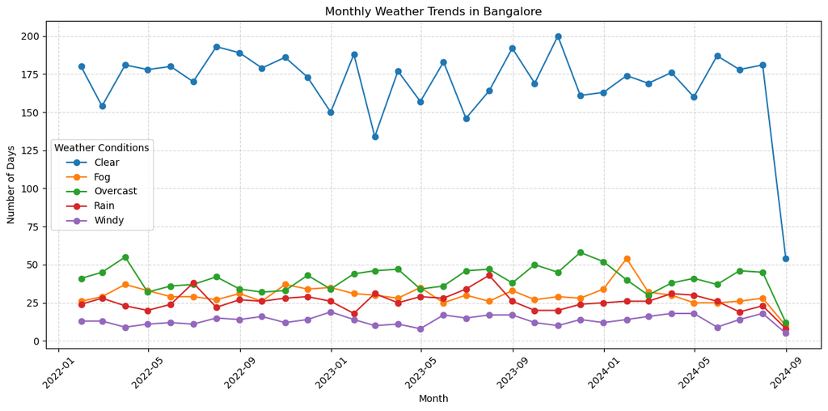

```python
import matplotlib.pyplot as plt

# Select weather columns
weather_cols = ['Clear', 'Fog', 'Overcast', 'Rain', 'Windy']

# Plot line chart for weather trends
plt.figure(figsize=(12,6))

for col in weather_cols:
    plt.plot(monthly_exog.index, monthly_exog[col], marker='o', label=col)

plt.title("Monthly Weather Trends in Bangalore")
plt.xlabel("Month")
plt.ylabel("Number of Days")
plt.xticks(rotation=45)
plt.grid(True, linestyle='--', alpha=0.5)
plt.legend(title="Weather Conditions")
plt.tight_layout()
plt.show()
```

# Conclusion of the Dataset :

#### Overall, the data highlights key high-traffic zones, peak congestion areas, and temporal patterns that can help in traffic planning and congestion management strategies.

###### Project done by A.Benedict Paul (Big Data Analytics)